# Is portfolio diversification possible with S&P500 stocks?

First, load packages

```python
import networkx as nx
import numpy as np
import sys
import matplotlib.pyplot as plt
import pandas as pd
import seaborn as sns
import yfinance as yf
```

```python
tickers = ['AXON','BA',	'HWM','LMT','NOC','ROST','LULU','NKE','TPR','VFC','ADBE','FICO','INTU','ORCL','SNPS','F','GM',
           'TSLA','ABBV','GILD','MRNA','REGN','VRTX','CVX','XOM','HES','NFLX','PARA','DIS','HAL','SLB','AAPL','HPE',
  'HPQ','NTAP','STX','MA','PYPL','V']
```

Download data from Yahoo Finance

```python
data= yf.download(tickers, start="2022-03-01", end="2024-03-01")
data = data['Adj Close']
log_returns = np.log(data/data.shift())
```

```
[*********************100%%**********************]  39 of 39 completed
```

Calculate correlation of returns

```python
corr_m=log_returns.corr()
corr_m = np.asmatrix(corr_m)
```

Plot the correlation matrix as a heat map

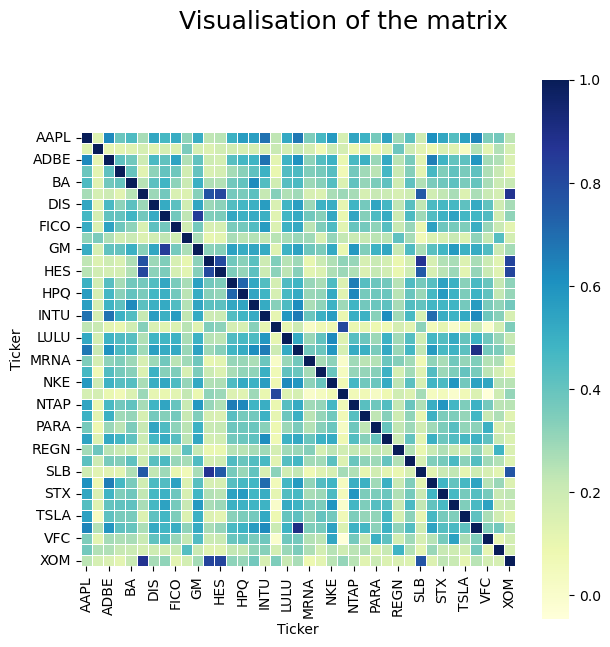

```python
corr_figure=log_returns.corr()
plt.subplots(figsize=(7,7))
plt.suptitle('Visualisation of the matrix',fontsize=18)
sns.heatmap(corr_figure,square=True,cmap="YlGnBu", linewidth=0.5)
```

The heat map shows that most correlations tend to be below 60%. The diagonal has self-correlations and is obviously equal to 100%. From a risk diversification perspective this is promising. It would be better if there were more negative correlations.

Let's see the pairwise correlations as a network

```python
matrix_array=np.array(corr_m)
matrix_corr=np.matrix(matrix_array,copy=False,dtype=None)
```

Remove the correlation values=1 ie the self-correlations

```python
matrix_corr_filtered=np.where(matrix_corr!=1.0,matrix_corr,0)
```

```python
nodes_assets=tickers
Graph_asset=nx.from_numpy_array(matrix_corr_filtered)
```

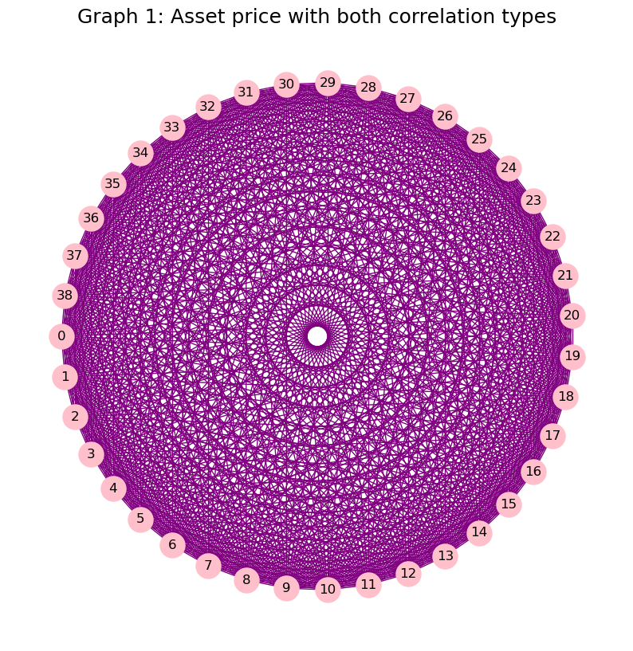

```python
plt.subplots(figsize=(10,10))
nx.draw_shell(Graph_asset,with_labels=True,node_color='pink',node_size=500,edge_color='purple')
plt.title('Graph 1: Asset price with both correlation types',fontsize=18)
plt.show()
#plt.savefig('dow_30_corr_coeff_circular.png')
```

Let's have a look at the negative and positive correlations. First, define two separate matrices that will contain the two different types.

```python
matrix_new=np.array(matrix_corr_filtered)
positive_corr=np.where(matrix_new>0,matrix_new,0)
negative_corr=np.where(matrix_new<0,matrix_new,0)
```

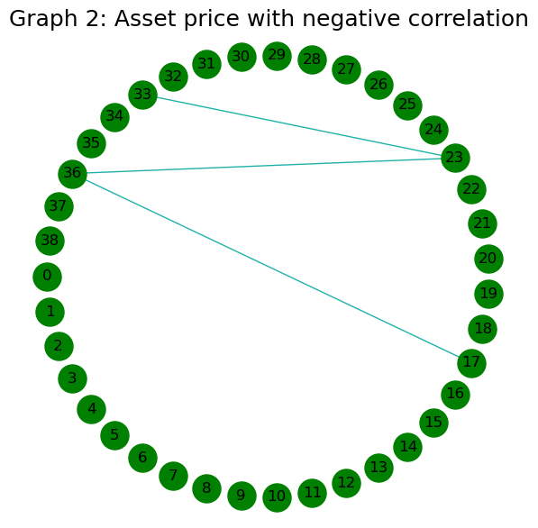

```python
Graph_asset_negative=nx.from_numpy_array(negative_corr)
plt.subplots(figsize=(7,7))
nx.draw_shell(Graph_asset_negative,with_labels=True,node_color='green',node_size=500,edge_color='lightseagreen')
plt.title('Graph 2: Asset price with negative correlation',fontsize=18)
plt.show()
```

Shockingly, there are only 3 negative correlations in this subsample of the S&P500. Maybe the sample is biased, but the stocks were chosen from very differnt industries, and theoretically more should be negatively correlated. choice of industries was varied.

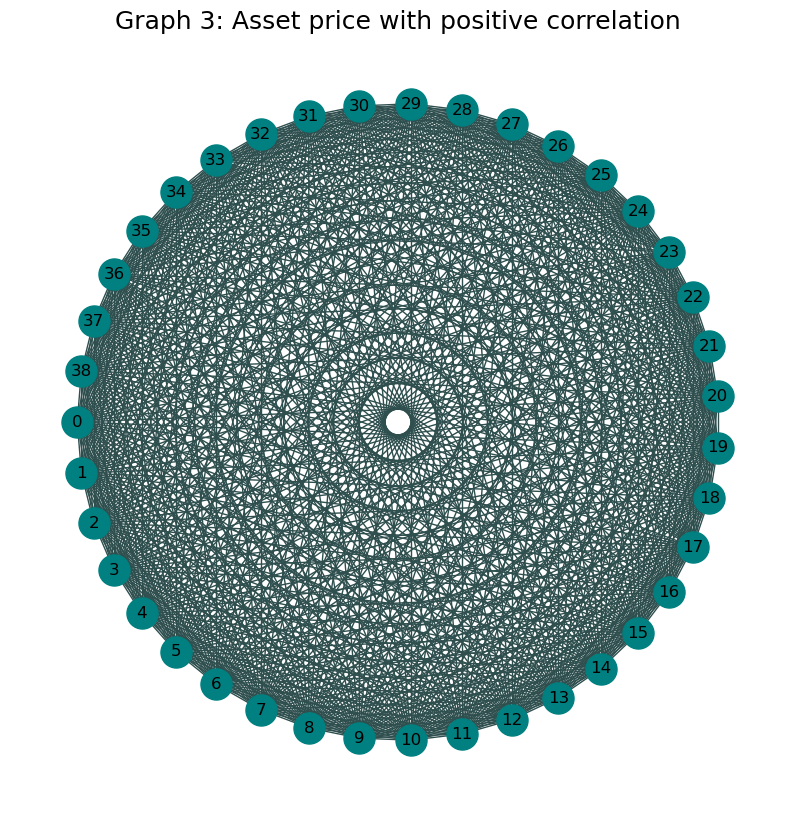

```python
Graph_asset_positive=nx.from_numpy_array(positive_corr)
plt.subplots(figsize=(10,10))
nx.draw_shell(Graph_asset_positive,with_labels=True,node_color='teal',node_size=500,edge_color='darkslategrey')
plt.title('Graph 3: Asset price with positive correlation',fontsize=18)
plt.show()
```

This network is virtually the same as the first graph.

# Reference

Lopez De Prado, M. (2018), Advances in financial machine learning, Wiley